# Class 10: Machine Learning Project

Tiffany Luong

2/7/2020

Recap from last week: tinyurl.com/BARRYMD kmeans(x, centers = #) hclust(dist(x)) PCA = prcomp(x, scale = T)

## Get our input data

Our data from today comes from the Breast Cancer Diagnostic Data Set:

```r
# Save your input data file to a new 'data' directory

wisc.df <- read.csv("WisconsinCancer.csv")
head(wisc.df)
attributes(wisc.df)
```

We want numerical values only!

```r
wisc.data <- as.matrix(wisc.df[,3:32])
head(wisc.data)
```

> Q. How many patients are there in this dataset?

```r
nrow(wisc.df)
```

```
## [1] 569
```

> Q. How many cancer and non-cancer patients are there?

```r
sum(wisc.df$diagnosis == "M")
```

```
## [1] 212
```

```r
table(wisc.df$diagnosis)
```

```
##
##   B   M
## 357 212
```

> Q. How many cols are "_mean" values?

```r
colnames(wisc.df)
```

We can use the `grep()` function combined with the `length` function to see this:

```r
length(grep("_mean", colnames(wisc.df), value = TRUE))
```

```
## [1] 10
```

## Enter Principal Component Analysis

First we need to check whether our input data should be scaled.

For apply row = 1, column = 2.

Let’s check the sd() and mean() of all our columns in `wisc.data`.

To make the #’s more legible, use `round` round(x, #sig figs).

```r
round(apply(wisc.data, 2, sd), 2)

round(apply(wisc.data, 2, mean), 2)
```

```r
#Perform PCA on wisc.data by completing the following code
wisc.pr <- prcomp(wisc.data, scale = TRUE)
summary(wisc.pr)
```

> Q7. From your results, what proportion of the original variance is captured by the first principal components (PC1)? 44.27 Q8. How many principal components (PCs) are required to describe at least 70% of the original variance in the data? 3 Q9. How many principal components (PCs) are required to describe at least 90% of the original variance in the data? 7

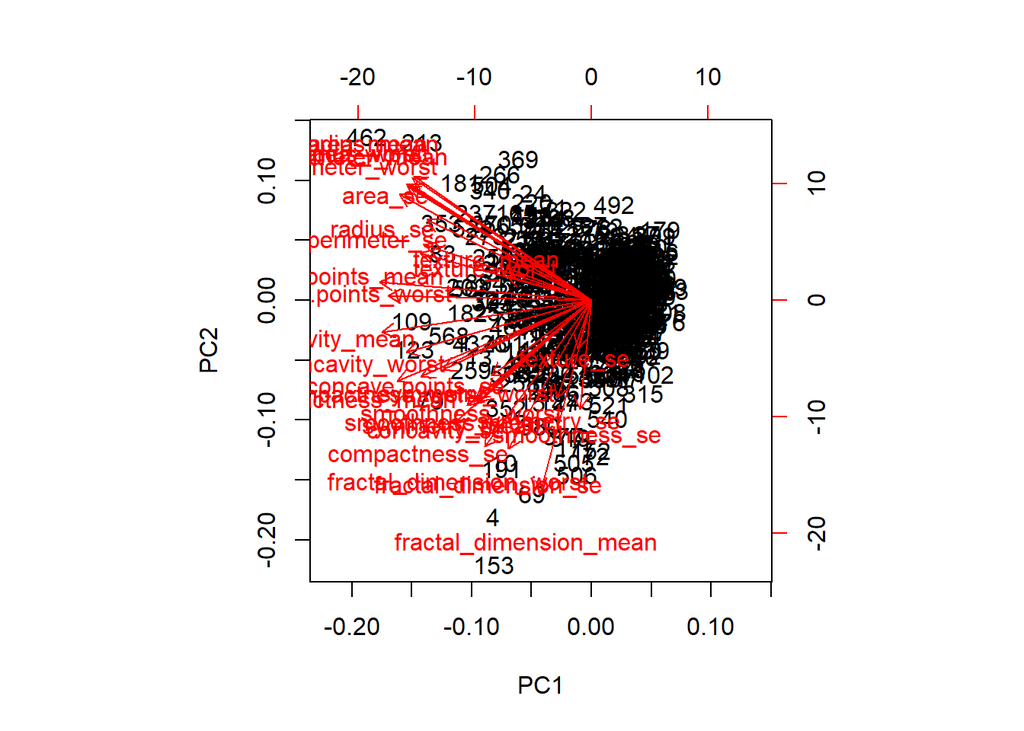

```r
biplot(wisc.pr)
```

This is a hot mess! We need to cook our own PCA plot.

```r
attributes(wisc.pr)
```

```
## $names
## [1] "sdev"     "rotation" "center"   "scale"    "x"
##
## $class
## [1] "prcomp"
```

We want the $x component to make the plot!

The same thing would be plot(wisc.pr$x[,1], wisc.pr$x[,2], col=wisc.df$diagnosis).

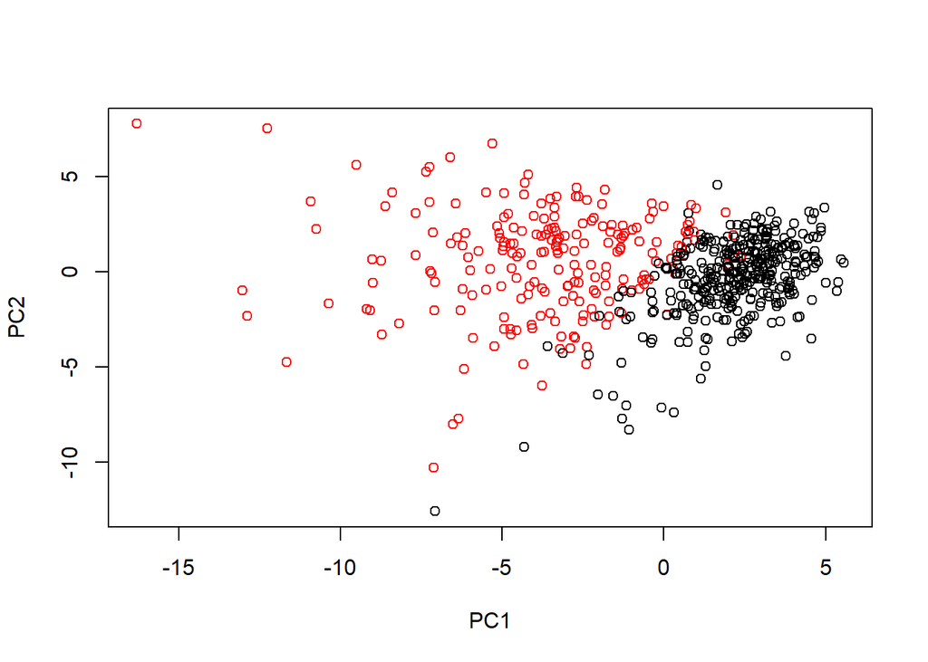

```r
plot(wisc.pr$x[,1:2], col=wisc.df$diagnosis)
```

Wow, this looks cool! There is a seperation of the red (cancer) from black (non-cancer) samples.

## Hierarchical clustering

Can we find a seperation of cancer from non-cancer using a clustering method on the original input data?

For this we will use the `hclust()` function on the `wisc.data` object that we used for PCA.

Now let’s cluster it:

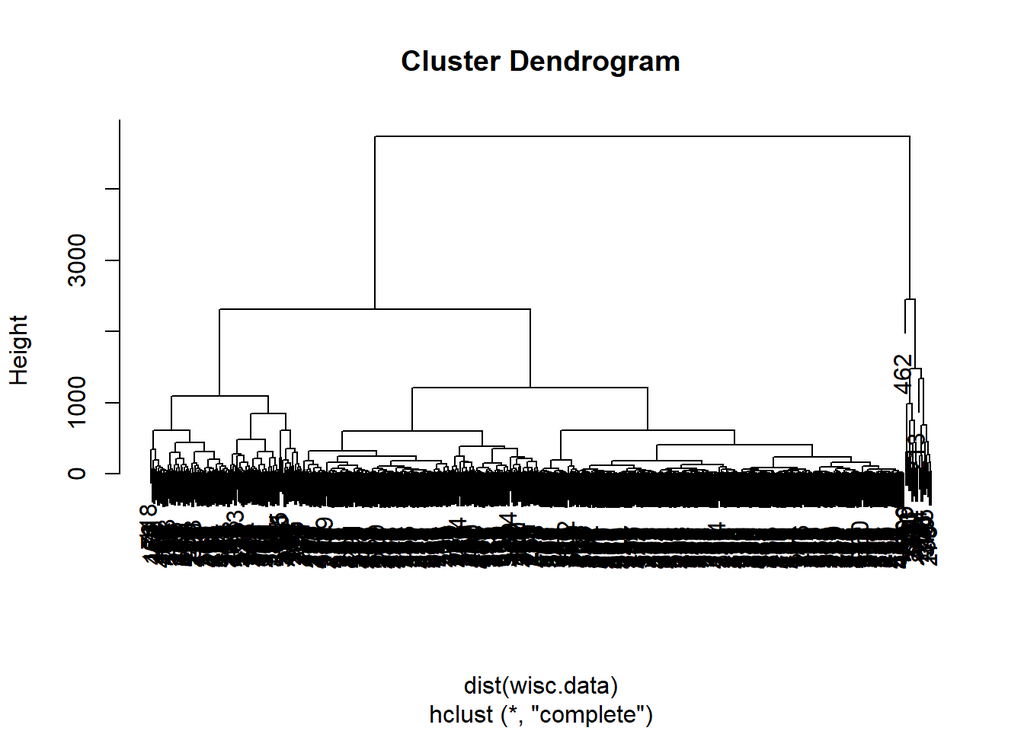

```r
#Create a hierarchical clustering model using complete linkage. Manually specify the method argument to hclust() and assign the results to wisc.hclust.

wisc.hc <- hclust(dist(wisc.data), method = "complete")

plot(wisc.hc)
```

Where are you supposed to *cut* a tree like this???

```r
wisc.hc.cut <- cutree(wisc.hc, k = 4)

table(wisc.hc.cut, wisc.df$diagnosis)
```

```
##
## wisc.hc.cut   B   M
##           1   1 110
##           2 356  82
##           3   0  19
##           4   0   1
```

But this division doesn’t seem correct…

I can cluster in PC space - in other words, use the results of PCA to cluster!

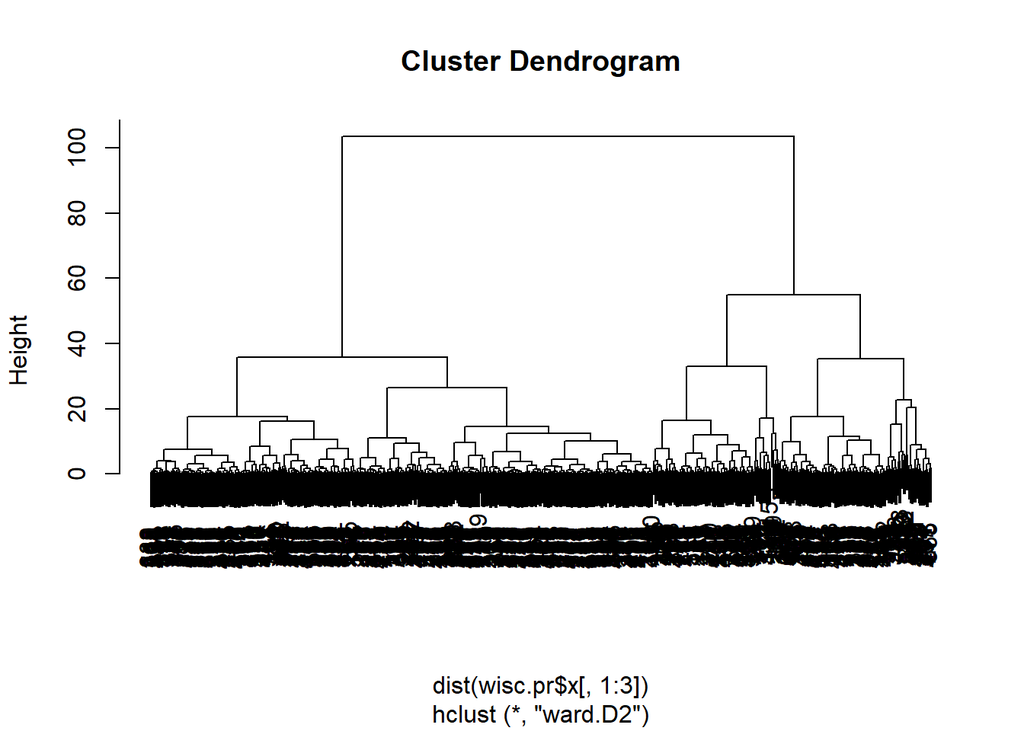

```r
wist.pr.hc <- hclust(dist(wisc.pr$x[,1:3]), method="ward.D2")
plot(wist.pr.hc)
```

```r
grps <- cutree(wist.pr.hc, k =2)
table(grps)
```

```
## grps
##   1   2
## 203 366
```

```r
table(grps, wisc.df$diagnosis)
```

```
##
## grps   B   M
##    1  24 179
##    2 333  33
```

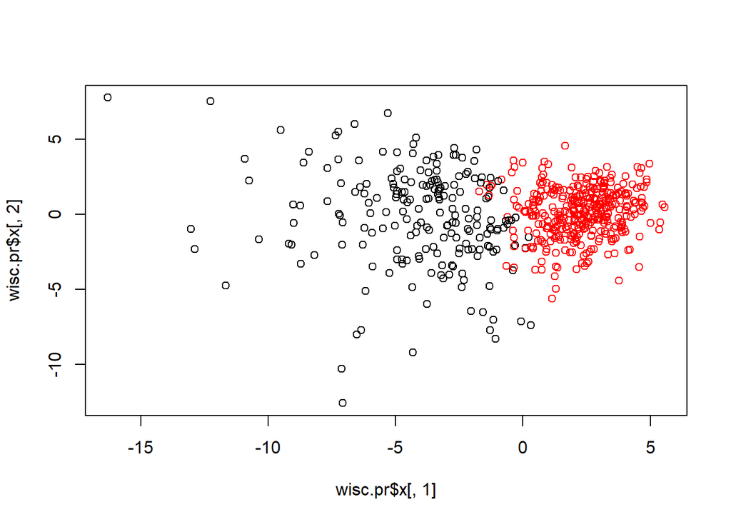

```r
plot(wisc.pr$x[,1], wisc.pr$x[,2], col=grps)
```

## Prediction using our PCA model

We will use the `predict()` function that will take our PCA model from before and new cancer cell data and project that data onto our PCA space.

```r
url <- "https://tinyurl.com/new-samples-CSV"
new <- read.csv(url)
npc <- predict(wisc.pr, newdata=new)
npc
```

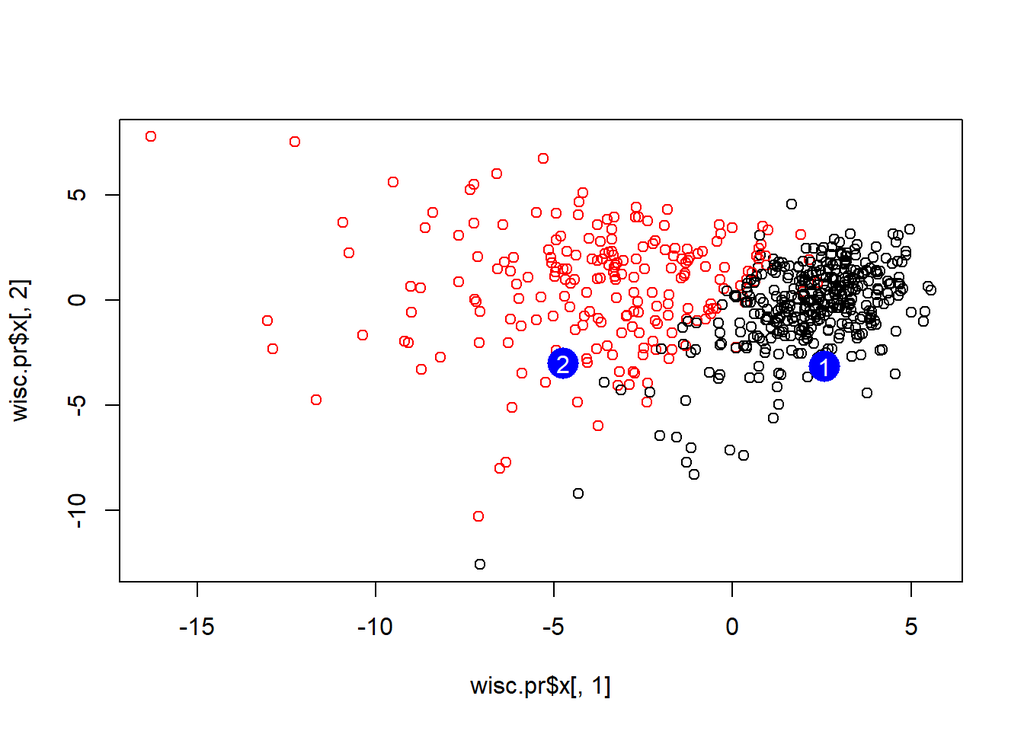

```r
plot(wisc.pr$x[,1], wisc.pr$x[,2], col=wisc.df$diagnosis)
points(npc[,1], npc[,2], col="blue", pch=16, cex=3)
text(npc[,1], npc[,2], labels=c(1,2), col="white")
```